# The post-PhD academic job

PG conference 2024 ~ 3 June

## Agenda

**Note 1:** This 1-hour workshop is just a taster!

**Note 2:** This is specifically about academic jobs - there are lots of other opportunities outside of academia for PhD-holders

- The goal is to get you thinking about the job market, strategies for approaching it, and present the more human side of things, i.e., our personal experiences.
- Most of what we will say can apply to both post docs and permanent positions, but we probably **won’t** have time to cover permanent position job visit and interview processes

**The Plan:**

- Some general and higher-level tips for approaching the job market
- Panel questions, and questions from you!

## Situating things

### Challenges/stresses

- Competitive
- Time consuming
- Uncertainty about future

### Mitigation

- Sometimes fun (?) to think about your research, talk about it, and tell people about things you like
- Sources of support exist
- Exciting and rewarding

## Sources of support

- Your supervisor(s)
  - They have done this before, though perhaps a while ago; they may engage to varying degrees with you in the job search process
- Your peers in the PhD programme
  - They are in the same situation you are in - commiseration, sharing resources, tips etc.
- Career resources from Uni, elsewhere
  - Generally very good, more expertise than academics
- Family and Friends
  - Emotional support

## Sources of support: Career center

Lots of resources and information - UoE students can book appointments

[figure not shown]

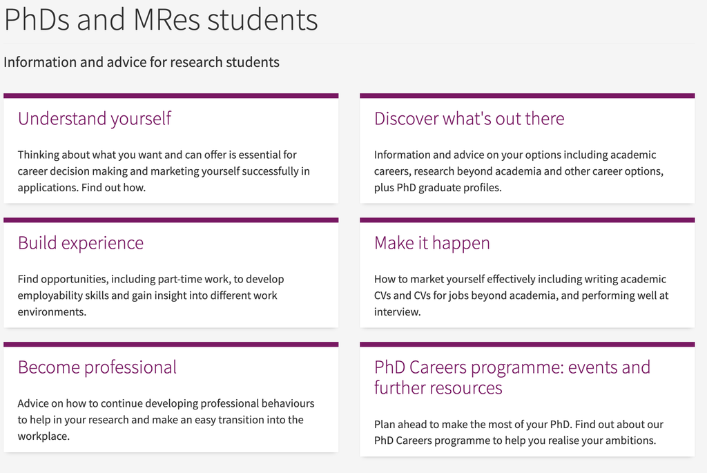

## Planning - explicit

**1** Strategy about what to apply for and when

**2** Marketing yourself

**3** Putting together application materials and preparing interviews

- When to do this? I suggest starting to think about these one year prior to your planned graduation date

## Planning - explicit

**1 Strategy about what to apply for and when**

- Consider your constraints, what is a must-have for you in a job?
  - e.g., located in X; research-focused job, etc.
  - these can change as you change!
- Consider your desirables, what do you *want* from a job?
- General advice: cast a wide net with applications, but only for jobs that fit your must-have criteria

## Planning - explicit

**2 Marketing yourself**

Though this will depend on the nature of the job; broadly, this means

- Talking about your research in way that is accessible and makes a case for your qualifications
- Identifying and emphasizing other skills that you have which are relevant to the job
- Making connections between what you offer and what they want

## Planning - explicit

**3 putting together application materials and interview prep**

- Research statement
- Letters of recommendation
- CV
- Cover letter
- Preparing for interviews
  - researching the job, employer, department
  - mock interviews with colleagues/supervisors
  - doing interviews

## Implicit planning, and the “hidden cirriculum”

IMO - one of the best things you can do to prepare for employment is to make the most of your PhD time and build skills organically

(Easier said than done, esp. given the time constraints)

- Doing research and writing thesis
- Tutoring
- Other transferable skills not directly related to thesis
- Publishing papers, when possible
- Building connections with other researchers

## Panel Questions

## Panel Questions

1. What is one thing you wish you had known before going on the job market?
2. What did you do to prepare for going on the job market prior to submitting any applications?
3. What sources of support/guidance did you make use of when applying for jobs?
4. What are some specific things that you did during your PhD which helped you be successful on the job market?
5. Tell us briefly about one or two interview experiences you’ve had. What went well, and what didn’t? What surprised you if anything?
6. What would you do differently now, if anything?